# 华为供应链难题0222思路整理

## 一. 华为需求整理

通过华为提供的材料，归纳整理了他们的难题与需求。

1. 预测算法建模过程可解释性

   ```
    1.1 形成一个算法库与一个业务场景库，最终目标是在每一个特定业务场景对应至少一个模型库中的模型，进行模型推荐。

    1.2 梳理出数据分类特点（比如连续、稳定、相关性、新产品、老产品等），整理归纳数据分类的业务含义。

    1.3 每一类数据需要匹配的算法特点，适用于什么算法？每个特征对模型的影响？
   ```

2. 预测模型结果可解释性

   ```
    2.1 将属性类业务因子（历史发货量、需求波动率、发货频率）与约束类业务因子（未来需求、版本切换、总量控制、配比关系）融入模型，帮助模型建立可解释性框架；进一步针对业务因子的变化对模型进行自动调参。

    2.2 提供时间序列上的预测模型调控，不需人工调控，自动输出结果。
   ```

3. 人机交互

   ```
    3.1 将上述需求整合，建立一个人机交互的环境。
   ```

[figure not shown]

## 二. 思考

### 需求1.1的思考

哪些业务场景的变量对模型的选择有影响

1. 需要预测的时间序列的长度
2. 已有数据长度
3. 根据数据特点划分的场景（新老产品更新、连续、稳定）
4. 根据属性业务因子赋予的数据特性的分类场景

需求1.1的解决方法就是建立模型库，再对上面的不同变量做一个统一的模型测试与归纳。

### 需求1.2的思考

从数据自身的意义与供应链系统动力学梳理出数据分类特点，整理归纳数据分类的业务含义。

可以进一步使用聚类算法来得到更抽象的数据特征与分类意义。

### 需求1.3的思考

构建模型库，分为三个模块对模型与业务场景进行匹配

1. 模型自身特点，比如灰度模型适用于少数据量的数据与短序列预测，Informer适用于长序列预测但需要大量数据，ARIMA适用于短序列季节性预测，Prophet适用于趋势预测
2. 实际模型效果，每个业务场景下对每个模型进行尝试，选出最优模型
3. 业务场景可解释性要求，针对不同的业务场景，有些场景需要模型具有可解释性，有些场景只需要模型输出的结果，针对这个问题，对不同业务场景的模型需求在可解释性上进行划分

### 需求2.1的思考

基于因果推断，进行因果发现，构建因果图，考察处理变量对结果变量的因果影响，这里的处理变量为业务因子，结果变量为需求数量，因果影响就是调控的具体数值，最终构建一个解释模型。

相关方法有线性回归的因果推断、因果森林等等方法。

### 需求2.2的思考

在华为的描述中，有提到 “提供时间序列预测场景下的状态state、调控action、评估reward调控模型”，这是一个标准的强化学习框架的基本元素。强化学习可以做时间序列上的策略制定，非常符合华为的描述。

相关的模型有SARSA、Q-Learner、深度强化学习模型等等。

这个是我之前的一个强化学习dyna-Qlearner在组合投资策略选取的应用 https://zhenz2020.github.io/ml4t/strategyEval_report.pdf

### 需求3.1的思考

这个是我之前为一个音乐公司做的一个收听量预测的web app，也是一个人机交互的场景 https://p3bvl1-zhenz2020.shinyapps.io/Stat427-project/?_ga=2.24823482.166748252.1677064621-1030429554.1677064621

## 三. 数据基础分析

```python
import pandas as pd
import matplotlib.pyplot as plt
plt.rcParams['font.sans-serif'] = ['SimHei']
data = pd.read_csv(r'脱敏测试数据.csv')
```

```python
data.columns = ['ITEM', 'QTY', 'ITEM_TYPE', 'TYPE2', 'DATE', 'REPOFFICE', 'DEPT', 'REGION',
       'STATUS', 'MONDAY', 'YEAR_MONTH', 'YEAR_QUARTER', 'YEAR', 'MONTH', 'INDUSTRY']
data.iloc[:10,:]
```

|  | ITEM | QTY | ITEM_TYPE | TYPE2 | DATE | REPOFFICE | DEPT | REGION | STATUS | MONDAY | YEAR_MONTH | YEAR_QUARTER | YEAR | MONTH | INDUSTRY |
| --- | --- | --- | --- | --- | --- | --- | --- | --- | --- | --- | --- | --- | --- | --- | --- |
| 0 | 04041306 | 3 | P | P | 2021/6/23 | 北京 | DEPT01 | 华北 | GA | 20210621 | 202106 | 2021Q2 | 2021 | 6 | 行业06 |
| 1 | 04041306 | 3 | P | P | 2021/6/4 | 北京 | DEPT01 | 华北 | GA | 20210531 | 202106 | 2021Q2 | 2021 | 6 | 行业06 |
| 2 | 04041306 | 3 | P | P | 2021/11/23 | 北京 | DEPT01 | 华北 | GA | 20211122 | 202111 | 2021Q4 | 2021 | 11 | 行业06 |
| 3 | 04041306 | 3 | P | P | 2021/8/15 | 北京 | DEPT01 | 华北 | GA | 20210809 | 202108 | 2021Q3 | 2021 | 8 | 行业06 |
| 4 | 04041306 | 3 | P | P | 2021/8/7 | 北京 | DEPT01 | 华北 | GA | 20210802 | 202108 | 2021Q3 | 2021 | 8 | 行业06 |
| 5 | 04041306 | 3 | P | P | 2020/10/13 | 北京 | DEPT01 | 华北 | GA | 20201012 | 202010 | 2020Q4 | 2020 | 10 | 行业06 |
| 6 | 04041306 | 3 | P | P | 2021/6/29 | 北京 | DEPT01 | 华北 | GA | 20210628 | 202106 | 2021Q2 | 2021 | 6 | 行业06 |
| 7 | 04041306 | 3 | P | P | 2021/12/21 | 北京 | DEPT01 | 华北 | GA | 20211220 | 202112 | 2021Q4 | 2021 | 12 | 行业06 |
| 8 | 04041306 | 3 | P | P | 2020/11/12 | 青海 | DEPT01 | 华西 | GA | 20201109 | 202011 | 2020Q4 | 2020 | 11 | 行业06 |
| 9 | 04041306 | 3 | P | P | 2021/1/6 | 宁夏 | DEPT01 | 华西 | GA | 20210104 | 202101 | 2021Q1 | 2021 | 1 | 行业06 |

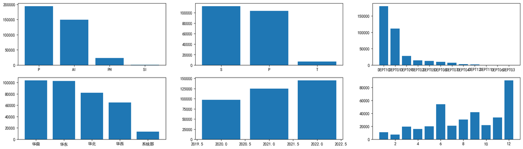

```python
plt.figure(figsize=(22,6))
plt.subplot(231)
IT=data['ITEM_TYPE'].value_counts()
plt.bar(IT.index,IT.values)

plt.subplot(232)
T2=data['TYPE2'].value_counts()
plt.bar(T2.index,T2.values)

plt.subplot(233)
D=data['DEPT'].value_counts()
plt.bar(D.index,D.values)

plt.subplot(234)
R=data['REGION'].value_counts()
plt.bar(R.index,R.values)

plt.subplot(235)
Y=data['YEAR'].value_counts()
plt.bar(Y.index,Y.values)

plt.subplot(236)
M=data['MONTH'].value_counts()
plt.bar(M.index,M.values)
plt.show()
```

## 四. 可解释模型

1. 因果推断

   ```
    基于观察数据进行反事实估计，分析干预与结果之间的因果关系。具体到本次数据，业务因子是我们可以干预的，通过数据因果发现与统计推断，得到业务因子与需求量间的因果关系
   ```

2. 系统动力学模型

   ```
    要求对供应链整个建模，分析上下游关系，理清各个变量，要求很高，难以实现
   ```

3. 聚类模型

   ```
    聚类提取抽象特征，加强可解释性
   ```

## 五. 可解释预测模型

1. 回归模型

   ```
    线性回归、广义线性回归、ridge、lasso
   ```

2. ARIMA

   ```
    最有名的时间序列预测算法之一。要求数据序列是平稳的，均值和方差不应随时间而变化，输入的数据是单变量序列

    ARIMA对序列绘图，进行 ADF 检验，观察序列是否平稳；对于非平稳时间序列要先进行 d 阶差分（季节特性），转化为平稳时间序列；然后对平稳时间序列分别求得其自相关系数（ACF）和偏自相关系数（PACF），通过对自相关图和偏自相关图的分析，得到最佳的阶数p、q
   ```

3. 强化学习

   ```
    “提供时间序列预测场景下的状态state、调控action、评估reward调控模型”，该描述符合马尔科夫决策过程，而强化学习就是使用马尔科夫决策过程来描述

    可以通过调控rewards的规则，利用约束业务因子对action规则进行调控，决策规则来进行模型可解释性构建，但需要注意的是，这里需要思考怎样将需求预测重新建模为马尔可夫决策过程
   ```

4. 灰色模型

   ```
    灰色预测的主要特点是适用于少量数据时使用(比如20个以内)，大量数据时不适合，输入的数据是单变量序列

    像GM（1，1）之类的灰色模型适用于短期预测

    论文：汪芸芳,史意,陈丽华.基于BP神经网络及灰色GM(1,1)模型的服装供应链第三方库存预测应用研究[J].数学的实践与认识,2020,50(03):277-285.
   ```

## 六. 难解释预测模型

1. 传统机器学习模型

   ```
    XGBoost、随机森林回归
   ```

2. 深度学习模型

   ```
    LSTM、Informer
   ```

## 七. 融合模型

```
    因果+贝叶斯=贝叶斯网络 （可解释性+预测分类模型）

    聚类+预测模型 （可解释性+预测模型）
```